# Prueba Z²

Análisis multivariado del rendimiento académico

Grupo 4

2026-09-14

## PREGUNTA 1

# 1.Introducción

El propósito del trabajo es analizar estadísticamente el comportamiento del rendimiento académico, no solo considerando cada variable de manera individual, sino también las relaciones que pueden existir entre ellas. El enfoque multivariado permite estudiar simultáneamente las cuatro variables cuantitativas y evaluar si su comportamiento conjunto presenta diferencias respecto a determinados valores de referencia. De esta manera, se busca obtener una visión más completa de la información que la que se obtendría mediante el análisis separado de cada variable.

El método empleado corresponde a un análisis estadístico de carácter descriptivo e inferencial, con énfasis en técnicas de estadística multivariada. La parte descriptiva permite resumir y explorar las características de los datos, mientras que la parte inferencial permite realizar contrastes de hipótesis sobre el comportamiento conjunto de las variables. Para ello, se consideran los supuestos estadísticos necesarios para la aplicación de las pruebas utilizadas.

### 1.1.Objetivo:

Determinar, mediante la prueba Z² multivariada, si el vector de medias poblacionales de las calificaciones de Matemática, Ciencia, Lenguaje e Historia difiere del vector de referencia $(14,14,15,15)$, considerando una matriz de varianza-covarianza conocida.

```r
library(pacman)
pacman::p_load(nortest,gtExtras,sjPlot,summarytools,GGally,BSDA,inferr,mvnormtest,MVTests,MVN,tidyverse,ggstatsplot,effectsize,car,reshape2,ggthemes,ggpubr,ICSNP,heplots,biotools,ergm,rrcov,Hotelling,echarts4r,gganimate,hrbrthemes,png,gifski,tinytable,readxl)
```

# 2.Lectura y descripción de los datos

### 2.2.Lectura de la base de datos

```r
datos = read_xlsx("Data_Colegio_Final.xlsx")
tt(head(datos))
```

| ID | Mate | Ciencia | Lenguaje | Historia | Turno |
| --- | --- | --- | --- | --- | --- |
| 1 | 14.5 | 13.5 | 13.5 | 12.8 | Tarde |
| 2 | 9.0 | 6.9 | 13.8 | 13.1 | Tarde |
| 3 | 13.5 | 14.0 | 15.6 | 15.1 | Tarde |
| 4 | 13.9 | 12.9 | 14.8 | 16.0 | Mañana |
| 5 | 12.8 | 11.2 | 14.8 | 13.4 | Tarde |
| 6 | 12.5 | 12.9 | 15.5 | 15.0 | Tarde |

```r
tt(tail(datos))
```

| ID | Mate | Ciencia | Lenguaje | Historia | Turno |
| --- | --- | --- | --- | --- | --- |
| 45 | 16.0 | 10.9 | 14.0 | 15.0 | Mañana |
| 46 | 14.5 | 15.1 | 13.0 | 14.3 | Mañana |
| 47 | 7.3 | 8.1 | 15.4 | 13.6 | Tarde |
| 48 | 14.4 | 12.6 | 16.6 | 15.5 | Mañana |
| 49 | 14.8 | 14.5 | 17.8 | 13.9 | Tarde |
| 50 | 15.5 | 16.6 | 13.3 | 12.9 | Mañana |

```r
glimpse(datos)
```

```
## Rows: 50
## Columns: 6
## $ ID       <dbl> 1, 2, 3, 4, 5, 6, 7, 8, 9, 10, 11, 12, 13, 14, 15, 16, 17, 18…
## $ Mate     <dbl> 14.5, 9.0, 13.5, 13.9, 12.8, 12.5, 12.2, 13.2, 11.5, 15.0, 12…
## $ Ciencia  <dbl> 13.5, 6.9, 14.0, 12.9, 11.2, 12.9, 13.4, 11.5, 12.9, 15.9, 11…
## $ Lenguaje <dbl> 13.5, 13.8, 15.6, 14.8, 14.8, 15.5, 15.8, 12.6, 15.7, 14.2, 1…
## $ Historia <dbl> 12.8, 13.1, 15.1, 16.0, 13.4, 15.0, 14.6, 12.0, 14.9, 14.8, 1…
## $ Turno    <chr> "Tarde", "Tarde", "Tarde", "Mañana", "Tarde", "Tarde", "Tarde…
```

### 2.2.Descripción de la muestra utilizada

Para efectos del ejercicio en estudio, se utilizaron las 50 observaciones disponibles de la base de datos lo que permite realizar inferencias estadísticas sobre el comportamiento general del rendimiento académico bajo ciertos supuestos, como la normalidad multivariada y la estructura de covarianza entre las variables.

```r
datosp1 = datos
head(datosp1)
```

```
## # A tibble: 6 × 6
##      ID  Mate Ciencia Lenguaje Historia Turno
##   <dbl> <dbl>   <dbl>    <dbl>    <dbl> <chr>
## 1     1  14.5    13.5     13.5     12.8 Tarde
## 2     2   9       6.9     13.8     13.1 Tarde
## 3     3  13.5    14       15.6     15.1 Tarde
## 4     4  13.9    12.9     14.8     16   Mañana
## 5     5  12.8    11.2     14.8     13.4 Tarde
## 6     6  12.5    12.9     15.5     15   Tarde
```

### 2.3.Análisis exploratorio de la muestra

Se realiza una revisión inicial de la base de datos para observar las primeras y últimas observaciones y conocer su estructura.

La variable `ID` solamente identifica a cada estudiante, por lo que no participa en el análisis estadístico.

```r
datosp1 = datosp1[,-1]
datosp1$Turno = as.factor(datosp1$Turno)
glimpse(datosp1)
```

```
## Rows: 50
## Columns: 5
## $ Mate     <dbl> 14.5, 9.0, 13.5, 13.9, 12.8, 12.5, 12.2, 13.2, 11.5, 15.0, 12…
## $ Ciencia  <dbl> 13.5, 6.9, 14.0, 12.9, 11.2, 12.9, 13.4, 11.5, 12.9, 15.9, 11…
## $ Lenguaje <dbl> 13.5, 13.8, 15.6, 14.8, 14.8, 15.5, 15.8, 12.6, 15.7, 14.2, 1…
## $ Historia <dbl> 12.8, 13.1, 15.1, 16.0, 13.4, 15.0, 14.6, 12.0, 14.9, 14.8, 1…
## $ Turno    <fct> Tarde, Tarde, Tarde, Mañana, Tarde, Tarde, Tarde, Mañana, Mañ…
```

### 2.4.Distribución por turno

```r
table(datosp1$Turno)
```

```
##
## Mañana  Tarde
##     23     27
```

### 2.5.Estadísticas descriptivas

Se obtienen las principales medidas descriptivas de las variables cuantitativas para conocer su tendencia central y variabilidad.

```r
summarytools::descr(datosp1)
```

```
## Descriptive Statistics
## datosp1
## N: 50
##
##                     Ciencia   Historia   Lenguaje     Mate
## ----------------- --------- ---------- ---------- --------
##              Mean     12.67      13.97      14.44    13.21
##           Std.Dev      2.14       1.75       1.86     1.84
##               Min      6.90       9.40       9.10     7.30
##                Q1     11.50      12.80      13.30    12.10
##            Median     12.55      14.10      14.80    13.10
##                Q3     14.10      15.00      15.50    14.60
##               Max     17.20      17.70      20.00    17.00
##               MAD      2.00       1.48       1.26     1.85
##               IQR      2.57       2.17       2.15     2.45
##                CV      0.17       0.13       0.13     0.14
##          Skewness     -0.24      -0.19      -0.21    -0.51
##       SE.Skewness      0.34       0.34       0.34     0.34
##          Kurtosis      0.02      -0.16       1.20     0.86
##           N.Valid     50.00      50.00      50.00    50.00
##                 N     50.00      50.00      50.00    50.00
##         Pct.Valid    100.00     100.00     100.00   100.00
```

**Interpretación:**Lenguaje presenta la mayor media, con 14.44 puntos, mientras que Ciencia presenta la menor, con 12.67 puntos. Matemática e Historia presentan medias de 13.21 y 13.97, respectivamente. La desviación estándar más alta corresponde a Ciencia, con 2.14 puntos, indicando una mayor dispersión de sus calificaciones respecto a las demás asignaturas.

# 3.Selección de variables para el análisis multivariado

### 3.1.Variables consideradas

Se consideran las cuatro variables cuantitativas: Matemática, Ciencia, Lenguaje e Historia.

```r
datos1 = datosp1[, 1:4]
tt(head(datos1))
```

| Mate | Ciencia | Lenguaje | Historia |
| --- | --- | --- | --- |
| 14.5 | 13.5 | 13.5 | 12.8 |
| 9.0 | 6.9 | 13.8 | 13.1 |
| 13.5 | 14.0 | 15.6 | 15.1 |
| 13.9 | 12.9 | 14.8 | 16.0 |
| 12.8 | 11.2 | 14.8 | 13.4 |
| 12.5 | 12.9 | 15.5 | 15.0 |

# 4.Análisis gráfico

### 4.1.Histogramas

Los histogramas permiten observar la distribución de las calificaciones de cada asignatura.

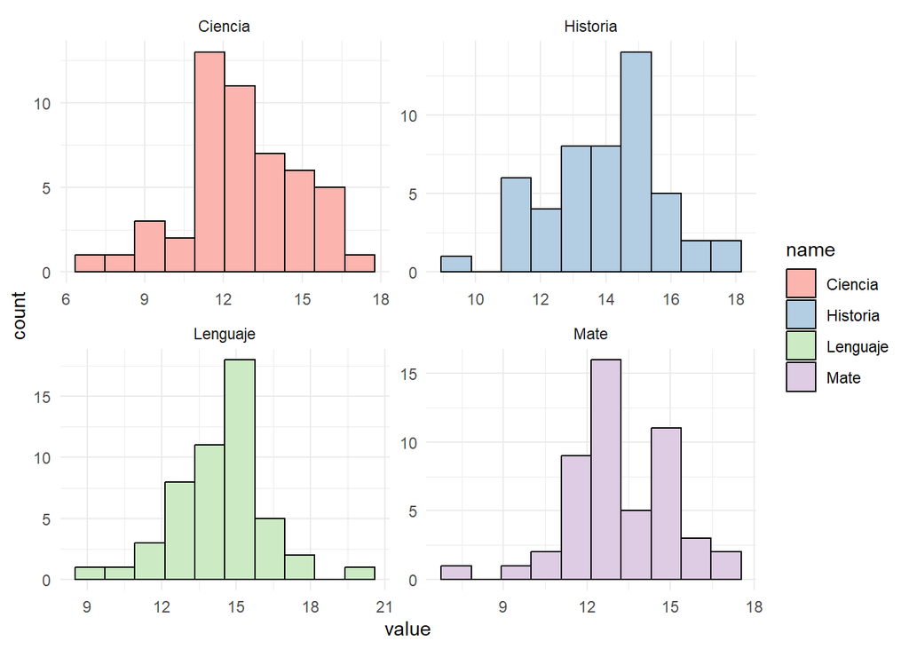

```r
datos_long <- pivot_longer(datos1, cols = 1:4)

ggplot(datos_long, aes(x = value, fill = name)) +
  geom_histogram(bins = 10, color = "black") +
  facet_wrap(~name, scales = "free") +
  theme_minimal() +
  scale_fill_brewer(palette = "Pastel1")
```

**Interpretación:**Se observan algunas calificaciones bajas, especialmente en Matemática y Ciencia. Estas observaciones representan estudiantes con menor rendimiento, aunque su consideración como valores atípicos debe basarse en el criterio estadístico del diagrama de cajas y no únicamente en que sean menores de 10.

### 4.2.Diagrama de cajas (Boxplot)

El diagrama de cajas permite comparar la distribución de las calificaciones entre las cuatro asignaturas.

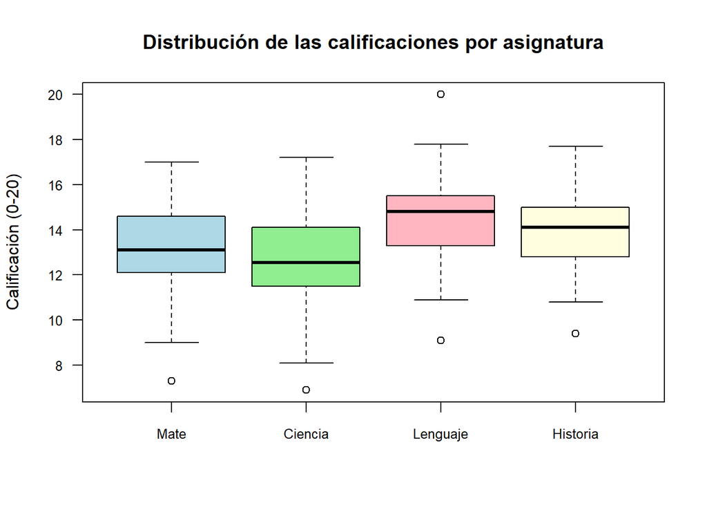

```r
boxplot(datos1,
        main = "Distribución de las calificaciones por asignatura",
        col = c("#ADD8E6", "#90EE90", "#FFB6C1", "#FFFFE0"),
        ylab = "Calificación (0-20)",
        las = 1,
        cex.axis = 0.8)
```

**Interpretación:**El gráfico muestra que el rendimiento académico es claramente superior en las materias de letras (Lenguaje e Historia), con medianas en torno a 14 y 15 puntos, en comparación con las de ciencias (Mate y Ciencia), cuyas medianas rondan los 12.5 y 13 puntos. Aunque la dispersión en el 50% central de las calificaciones es similar y moderada entre todas las áreas (rangos intercuartílicos cercanos a 2.5 puntos), todas presentan estudiantes rezagados con notas desaprobatorias atípicas (menores a 10), destacando Lenguaje por registrar, además, una calificación atípica perfecta de 20

# 5.Análisis de asociación entre las variables

### 5.1.Matriz de varianza-covarianza muestral

La matriz de varianza-covarianza permite analizar la variabilidad de cada asignatura y la relación conjunta entre las calificaciones.

Esta matriz corresponde a la covarianza calculada a partir de los datos y se utiliza únicamente para describir la estructura de asociación de la muestra. Para la prueba Z² se utilizará posteriormente una matriz de varianza-covarianza considerada conocida, de acuerdo con el supuesto del procedimiento

```r
sigma_muestral = cov(datos1)
sigma_muestral
```

```
##                Mate    Ciencia   Lenguaje   Historia
## Mate     3.38581633 2.73008163 0.02832653 0.01455102
## Ciencia  2.73008163 4.56491429 0.31737959 0.02252245
## Lenguaje 0.02832653 0.31737959 3.47353469 2.26749388
## Historia 0.01455102 0.02252245 2.26749388 3.06563673
```

La matriz muestra que existe una covarianza positiva alta entre Mate y Ciencia, y también entre Lenguaje e Historia, lo que indica que las notas de estos pares varían en la misma dirección (quien rinde alto en uno, tiende a rendir alto en el otro). En cambio, entre los demás pares de cursos la covarianza es casi cero, indicando que no tienen relación lineal entre sí. Finalmente Ciencia es la materia con mayor dispersión de notas, mientras que Historia es la más homogénea.

### 5.2.Matriz de Correlaciones

Permiten determinar la intensidad y dirección de la relación lineal entre las calificaciones de las diferentes asignaturas.

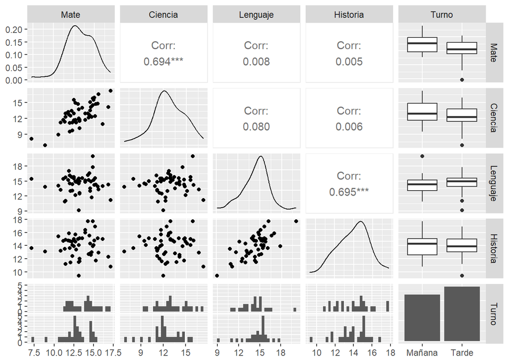

```
##                 Mate     Ciencia    Lenguaje    Historia
## Mate     1.000000000 0.694428637 0.008259921 0.004516494
## Ciencia  0.694428637 1.000000000 0.079703403 0.006020589
## Lenguaje 0.008259921 0.079703403 1.000000000 0.694864232
## Historia 0.004516494 0.006020589 0.694864232 1.000000000
```

```
##
##  Pearson's product-moment correlation
##
## data:  datos1$Mate and datos1$Ciencia
## t = 6.6862, df = 48, p-value = 2.227e-08
## alternative hypothesis: true correlation is not equal to 0
## 95 percent confidence interval:
##  0.5157768 0.8152035
## sample estimates:
##       cor
## 0.6944286
```

```
##
##  Pearson's product-moment correlation
##
## data:  datos1$Mate and datos1$Lenguaje
## t = 0.057228, df = 48, p-value = 0.9546
## alternative hypothesis: true correlation is not equal to 0
## 95 percent confidence interval:
##  -0.2707102  0.2859502
## sample estimates:
##         cor
## 0.008259921
```

```
##
##  Pearson's product-moment correlation
##
## data:  datos1$Mate and datos1$Historia
## t = 0.031292, df = 48, p-value = 0.9752
## alternative hypothesis: true correlation is not equal to 0
## 95 percent confidence interval:
##  -0.2741759  0.2825091
## sample estimates:
##         cor
## 0.004516494
```

```
##
##  Pearson's product-moment correlation
##
## data:  datos1$Ciencia and datos1$Lenguaje
## t = 0.55396, df = 48, p-value = 0.5822
## alternative hypothesis: true correlation is not equal to 0
## 95 percent confidence interval:
##  -0.2031513  0.3502801
## sample estimates:
##       cor
## 0.0797034
```

```
##
##  Pearson's product-moment correlation
##
## data:  datos1$Ciencia and datos1$Historia
## t = 0.041713, df = 48, p-value = 0.9669
## alternative hypothesis: true correlation is not equal to 0
## 95 percent confidence interval:
##  -0.2727843  0.2838926
## sample estimates:
##         cor
## 0.006020589
```

```
##
##  Pearson's product-moment correlation
##
## data:  datos1$Lenguaje and datos1$Historia
## t = 6.6943, df = 48, p-value = 2.165e-08
## alternative hypothesis: true correlation is not equal to 0
## 95 percent confidence interval:
##  0.5163943 0.8154857
## sample estimates:
##       cor
## 0.6948642
```

### 5.3.Interpretación de las relaciones entre variables

Se observa una asociación positiva importante entre Matemática y Ciencia, así como entre Lenguaje e Historia. Esto sugiere que ciertas dimensiones del rendimiento académico presentan un comportamiento conjunto, por lo que resulta pertinente complementar el análisis univariado mediante una metodología multivariada.

# 6.Caso Univariado

### 6.1.Análisis de normalidad de Matemática

Se toma Matemática como ejemplo para el análisis univariado.

### 6.1.1. Prueba de Shapiro-Wilk

Se aplican pruebas de normalidad y una prueba Z para una media con desviación estándar poblacional conocida.

```r
# Se toma Matemática como ejemplo del análisis univariado

d1 = datos1$Mate

# Prueba de Shapiro-Wilk

shapiro.test(d1)
```

```
##
##  Shapiro-Wilk normality test
##
## data:  d1
## W = 0.96884, p-value = 0.2075
```

Como el p-valor ($0.2075 > 0.05$) es mayor al nivel de significancia,por lo tanto no se rechaza $H_0$; No se encontró evidencia estadísticamente significativa para rechazar la normalidad de las calificaciones de Matemática.”

### 6.1.2.Prueba de Lilliefors

```r
lillie.test(d1)
```

```
##
##  Lilliefors (Kolmogorov-Smirnov) normality test
##
## data:  d1
## D = 0.082168, p-value = 0.5444
```

El p-valor ($0.5444 > 0.05$) ratifica la prueba anterior; no se rechaza $H_0$, por lo cual el resultado es consistente con el obtenido mediante Shapiro-Wilk.

### 6.2.Prueba Z para una media con desviación estándar conocida

```r
z.test(datos1$Mate,
       alternative = "two.sided",
       mu = 14,
       sigma.x = 2,
       conf.level = 0.95)
```

```
##
##  One-sample z-Test
##
## data:  datos1$Mate
## z = -2.7931, p-value = 0.005221
## alternative hypothesis: true mean is not equal to 14
## 95 percent confidence interval:
##  12.65564 13.76436
## sample estimates:
## mean of x
##     13.21
```

El p-valor ($0.0052 < 0.05$) indica que se rechaza $H_0$; la nota media poblacional es significativamente diferente de 14

### 6.3. Prueba para la desviación estándar

```r
#Prueba para la desviación estándar

ifr_os_var_test(datos,
                Mate,
                sd = 2,
                alternative = 'both')
```

```
##                            One-Sample Statistics
## ---------------------------------------------------------------------------
##  Variable    Obs    Mean     Std. Err.    Std. Dev.    [95% Conf. Interval]
## ---------------------------------------------------------------------------
##    Mate      50     13.21     0.2602       1.8401        1.284      2.8573
## ---------------------------------------------------------------------------
##
##              Two Tail Test
##             ---------------
##            Ho: sd(Mate) = 2
##            Ha: sd(Mate) != 2
##
##     Chi-Square Test for Variance
## -------------------------------------
##  Variable       c       DF      Sig
## -------------------------------------
##    Mate      41.476     49     0.4626
## -------------------------------------
```

Con un p-valor ($Sig = 0.4626 > 0.05$), no se rechaza $H_0$; no existe evidencia suficiente para afirmar que la desviación estándar sea distinta de 2 ($s = 1.84$).

# 7.Caso multivariado

### 7.1.Normalidad multivariada

Se considera simultáneamente las calificaciones de Matemática, Ciencia, Lenguaje e Historia.

### 7.2. Planteamiento del modelo multivariado

Antes de aplicar la prueba Z² se verifica el supuesto de normalidad multivariada.

```r
shapiro = mshapiro.test(t(datos1))
sp_valor = shapiro$p.value
shapiro
```

```
##
##  Shapiro-Wilk normality test
##
## data:  Z
## W = 0.96293, p-value = 0.1179
```

No se encontró evidencia suficiente para rechazar el supuesto de normalidad multivariada.

$$H_0: \mathbf{X} \sim
N_4(\boldsymbol{\mu},\boldsymbol{\Sigma})$$

$$H_1: \mathbf{X} \not\sim
N_4(\boldsymbol{\mu},\boldsymbol{\Sigma})$$
Se consideran conjuntamente las cuatro variables cuantitativas seleccionadas.

```r
tt(head(datos1))
```

| Mate | Ciencia | Lenguaje | Historia |
| --- | --- | --- | --- |
| 14.5 | 13.5 | 13.5 | 12.8 |
| 9.0 | 6.9 | 13.8 | 13.1 |
| 13.5 | 14.0 | 15.6 | 15.1 |
| 13.9 | 12.9 | 14.8 | 16.0 |
| 12.8 | 11.2 | 14.8 | 13.4 |
| 12.5 | 12.9 | 15.5 | 15.0 |

# 8.Procedimiento para la inferencia mediante Z²

### 8.1.Asignación de parámetros

```r
n <- 50       # Tamaño de la muestra
p <- 4         # Número de variables
mu <- c(14, 14, 15, 15)
```

### 8.2.Matriz de varianza-covarianza conocida

Para la prueba Z² se considera como conocida la siguiente matriz de varianza-covarianza:

```r
sigma <- matrix(c(4.2, 3.1, 0.5, 0.2,
                  3.1, 3.8, 0.4, 0.3,
                  0.5, 0.4, 3.5, 2.8,
                  0.2, 0.3, 2.8, 3.2),
                nrow = 4, byrow = TRUE)
sigma
```

```
##      [,1] [,2] [,3] [,4]
## [1,]  4.2  3.1  0.5  0.2
## [2,]  3.1  3.8  0.4  0.3
## [3,]  0.5  0.4  3.5  2.8
## [4,]  0.2  0.3  2.8  3.2
```

Para la aplicación de la prueba Z² se considera conocida la matriz de varianza-covarianza Σ establecida previamente para el problema. Esta matriz no se estima a partir de la muestra, sino que se incorpora como un parámetro conocido de la población.

### 8.3.Vector de medias muestrales

Se calculan las medias muestrales de Matemática, Ciencia, Lenguaje e Historia

```r
# VECTOR DE MEDIAS MUESTRALES


media_muestral <- colMeans(datos1)

media_muestral
```

```
##     Mate  Ciencia Lenguaje Historia
##   13.210   12.672   14.444   13.974
```

### 8.4.Planteamiento de hipótesis

Se plantean las siguientes hipótesis:

$$H_0:
\begin{pmatrix}
\mu_{Mate} \\
\mu_{Ciencia} \\
\mu_{Lenguaje} \\
\mu_{Historia}
\end{pmatrix}
=
\begin{pmatrix}
14 \\
14 \\
15 \\
15
\end{pmatrix}$$

$$H_1:
\begin{pmatrix}
\mu_{Mate} \\
\mu_{Ciencia} \\
\mu_{Lenguaje} \\
\mu_{Historia}
\end{pmatrix}
\neq
\begin{pmatrix}
14 \\
14 \\
15 \\
15
\end{pmatrix}$$
### 8.5.Nivel de significancia

$$\alpha = 0.05$$

### 8.6.Estadístico de prueba Z²

```r
media_muestral <- colMeans(datos1)
media_muestral
```

```
##     Mate  Ciencia Lenguaje Historia
##   13.210   12.672   14.444   13.974
```

```r
# Prueba Z² multivariada
Z2 <- t(media_muestral - mu) %*% solve(sigma / n) %*% (media_muestral - mu)

p_valor <- 1 - pchisq(Z2, df = p)

# Resultados
cat("Estadística Z^2:", Z2, "\n")
```

```
## Estadística Z^2: 44.96567
```

```r
cat("p-valor:", p_valor, "\n")
```

```
## p-valor: 4.04185e-09
```

```r
# Decisión
if (p_valor < 0.05) {
  cat("Rechazar H0: el vector de medias es diferente del vector de medias hipotético.\n")
} else {
  cat("No se puede rechazar H0: no hay suficiente evidencia para decir que el vector de medias es diferente del vector de medias hipotético.\n")
}
```

```
## Rechazar H0: el vector de medias es diferente del vector de medias hipotético.
```

### 8.7.Resultados y decisión

**Interpretación:**Existe evidencia estadísticamente significativa para afirmar que el vector de medias poblacionales de las calificaciones de Matemática, Ciencia, Lenguaje e Historia no coincide simultáneamente con el vector de referencia (14,14,15,15).

# 9.Prueba de Bartlett

### 9.1,Planteamiento de la prueba

```r
result <- Bcov(datos1, Sigma = sigma)

summary(result)
```

```
##        Bartlett's Test for One Sample Covariance Matrix
##
## Chi-Squared Value = 24.14741 , df = 10  and p-value: 0.00722
```

### 9.2. Resultados

La prueba de Bartlett mostró evidencia estadísticamente significativa de diferencia entre la matriz de covarianza muestral y la matriz especificada como conocida. Este resultado constituye un análisis complementario y debe considerarse al interpretar el procedimiento, ya que la prueba Z² fue aplicada bajo el supuesto teórico de que la matriz Σ es conocida.

# 10.Discusión

Los resultados exploratorios muestran que las calificaciones presentan comportamientos diferentes entre las asignaturas. Matemática y Ciencia presentan una asociación positiva relativamente alta, mientras que Lenguaje e Historia también muestran una asociación positiva importante. Este comportamiento evidencia que las variables no deben analizarse únicamente de manera aislada, lo que justifica el enfoque multivariado. La prueba Z² permitió evaluar simultáneamente las cuatro medias y mostró evidencia estadísticamente significativa de diferencia respecto al vector de referencia planteado. Sin embargo, la comparación mediante Bartlett mostró diferencias entre la matriz muestral y la matriz especificada, por lo que debe aclararse el origen y carácter conocido de la matriz utilizada en la prueba Z².

# 11.Conclusiones

**1.Sobre el objetivo principal**

La prueba Z² multivariada permitió contrastar simultáneamente las cuatro medias, evitando realizar únicamente contrastes separados para cada asignatura.

**2.Sobre la normalidad multivariada**

Los resultados indican que los datos presentan un comportamiento compatible con una distribución normal multivariada, ya que se obtuvo un p-valor de 0.1179, mayor que 0.05. Por lo tanto, no se rechaza la hipótesis de normalidad multivariada.

**3. Sobre el vector de medias**

La prueba Z² obtuvo un valor de 44.96567 y un p-valor de $4.04\times10^{-9}$, menor que 0.05. Por lo tanto, se rechaza $H_0$ y se concluye que el vector de medias del rendimiento académico difiere significativamente del vector de referencia $(14,14,15,15)$.

**4. Sobre la relación entre las variables**

Se encontró una asociación positiva importante entre Matemática y Ciencia, así como entre Lenguaje e Historia. Esto indica que los estudiantes que presentan un mayor rendimiento en una de estas variables tienden a presentar también un mayor rendimiento en la otra. En las demás variables, las asociaciones fueron débiles.

**5. Sobre la matriz de covarianzas**

La prueba de Bartlett obtuvo un p-valor de 0.00722, menor que 0.05. Por lo tanto, se rechaza la hipótesis de igualdad entre la matriz de covarianzas observada y la matriz de referencia. Este resultado debe considerarse al interpretar la prueba Z², debido a que esta se realizó bajo el supuesto de una matriz de covarianza conocida.

# 12.Bibliografía

- Anderson, T. W. (2003). *An Introduction to Multivariate Statistical Analysis*. Wiley.
- Johnson, R. A., & Wichern, D. W. (2007). *Applied Multivariate Statistical Analysis*. Pearson.

## PREGUNTA 2

# 1. Introducción

En la industria alimentaria, el aseguramiento de la calidad no puede limitarse a evaluar las características de un producto de forma aislada. Parámetros físicos esenciales de una galleta integral —como el peso, el diámetro, la humedad y el grosor— se encuentran estrechamente correlacionados debido al proceso de horneado y manufactura. Analizar cada variable por separado incrementa drásticamente el riesgo de cometer errores de tipo I en conjunto, ignorando la estructura multivariada del proceso.Para abordar esta problemática, el área de control de calidad de la panificadora busca determinar si el lote de producción actual cumple simultáneamente con los estándares establecidos en su ficha técnica, definidos por el vector objetivo $\boldsymbol{\mu}_0 = (\text{Peso: } 30.0\text{ g},\, \text{Diámetro: } 75.0\text{ mm},\, \text{Humedad: } 4.5\%,\, \text{Grosor: } 8.0\text{ mm})$. Dado que la verdadera matriz de varianza-covarianza del proceso es desconocida, se emplea una muestra aleatoria de $n = 150$ galletas y se aplica la prueba $T^2$ de Hotelling para una muestra.

# 2. Análisis exploratorio descriptivo de los datos

#### Activación de paquetes

```r
library(readxl)
library(knitr)
library(corrplot)
library(nortest)
library(gtExtras)
library(sjPlot)
library(summarytools)
library(effectsize)
library(GGally)
library(mvnormtest)
library(BSDA)
library(inferr)
library(mvnormtest)
library(MVTests)
library(MVN)
library(tidyverse)
library(effectsize)
library(car)
library(reshape2)
library(ggthemes)
library(ggpubr)
library(ICSNP)
library(heplots)
library(biotools)
library(ergm)
library(rrcov)
library(Hotelling)
library(echarts4r)
library(gganimate)
library(hrbrthemes)
library(png)
library(gifski)
library(tinytable)
library(rstatix)
```

### 2.1 Lectura de datos

Primeras 10 observaciones del registro de control de calidad de galletas integrales.

| id | peso | diametro | humedad | grosor |
| --- | --- | --- | --- | --- |
| 1 | 29.65 | 77.31 | 4.93 | 7.86 |
| 2 | 28.74 | 79.43 | 5.17 | 7.52 |
| 3 | 32.88 | 78.64 | 4.47 | 8.44 |
| 4 | 30.43 | 79.08 | 4.93 | 7.54 |
| 5 | 30.16 | 76.75 | 5.54 | 8.15 |
| 6 | 31.61 | 76.33 | 3.61 | 8.35 |
| 7 | 32.69 | 77.19 | 5.18 | 9.69 |
| 8 | 33.46 | 78.15 | 4.53 | 7.13 |
| 9 | 29.36 | 78.80 | 5.25 | 7.08 |
| 10 | 34.20 | 75.93 | 3.63 | 8.66 |

### 2.2 Estadísticos descriptivos

```
## Descriptive Statistics
## datos_galleta
## N: 150
##
##                     diametro   grosor   humedad       id     peso
## ----------------- ---------- -------- --------- -------- --------
##              Mean      74.68     7.83      4.78    75.50    29.68
##           Std.Dev       3.31     0.74      0.55    43.45     2.58
##               Min      64.38     5.92      3.32     1.00    21.99
##                Q1      72.62     7.30      4.40    38.00    28.02
##            Median      74.57     7.76      4.82    75.50    29.74
##                Q3      76.75     8.35      5.15   113.00    31.40
##               Max      84.00    10.03      6.22   150.00    36.62
##               MAD       3.09     0.72      0.55    55.60     2.48
##               IQR       4.11     1.02      0.75    74.50     3.36
##                CV       0.04     0.09      0.12     0.58     0.09
##          Skewness       0.03     0.28     -0.07     0.00    -0.26
##       SE.Skewness       0.20     0.20      0.20     0.20     0.20
##          Kurtosis       0.31    -0.07     -0.25    -1.22     0.23
##           N.Valid     150.00   150.00    150.00   150.00   150.00
##                 N     150.00   150.00    150.00   150.00   150.00
##         Pct.Valid     100.00   100.00    100.00   100.00   100.00
```

- Simetría y Distribución Normal: Los valores de asimetría están muy cercanos a cero en todas las variables. Asimismo, la curtosis se mantiene en niveles bajos.
- Consistencia entre Media y Mediana: Para cada variable, la media y la mediana son prácticamente idénticas. Esto confirma la ausencia de sesgos severos causados por valores atípicos extremos en el lote de producción.
- Variabilidad y Coeficiente de Variación (CV): El coeficiente de variación muestra que el diámetro es la variable más estable y homogénea del proceso, mientras que la humedad presenta la mayor variabilidad relativa, seguida por el peso y el grosor.

*Proximidad al Blanco Técnico: Confirmando los estadísticos anteriores, los valores centrales de la producción se alinean estrechamente con los requerimientos de la ficha técnica.*

### 2.3 Histogramas

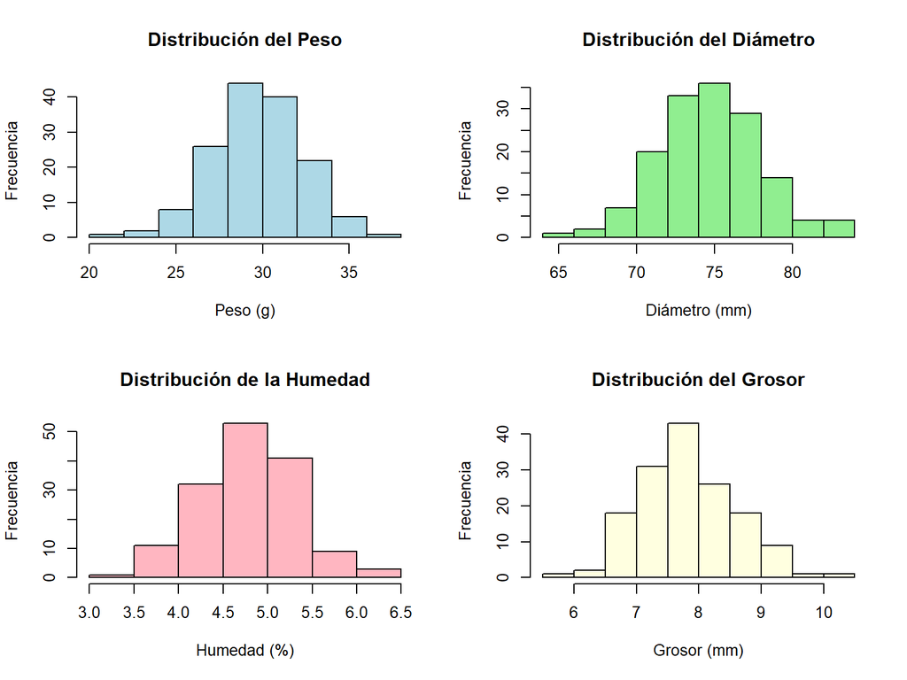

```r
par(mfrow = c(2, 2))

# 1. Histograma de Peso
hist(datos_galleta$peso,
     main = "Distribución del Peso",
     xlab = "Peso (g)",
     ylab = "Frecuencia",
     col = "lightblue")

# 2. Histograma de Diámetro
hist(datos_galleta$diametro,
     main = "Distribución del Diámetro",
     xlab = "Diámetro (mm)",
     ylab = "Frecuencia",
     col = "lightgreen")

# 3. Histograma de Humedad
hist(datos_galleta$humedad,
     main = "Distribución de la Humedad",
     xlab = "Humedad (%)",
     ylab = "Frecuencia",
     col = "lightpink")

# 4. Histograma de Grosor
hist(datos_galleta$grosor,
     main = "Distribución del Grosor",
     xlab = "Grosor (mm)",
     ylab = "Frecuencia",
     col = "lightyellow")
```

*Los cuatro histogramas muestran que el proceso de producción es estable, simétrico y se encuentra correctamente centrado respecto a los estándares de la ficha técnica. Al presentar una forma de campana bien definida sin valores atípicos extremos, se confirma visualmente que las variables cumplen con el comportamiento normal necesario y que el lote de galletas mantiene una calidad uniforme y alineada con el objetivo.*

### 2.4 BoxPlots

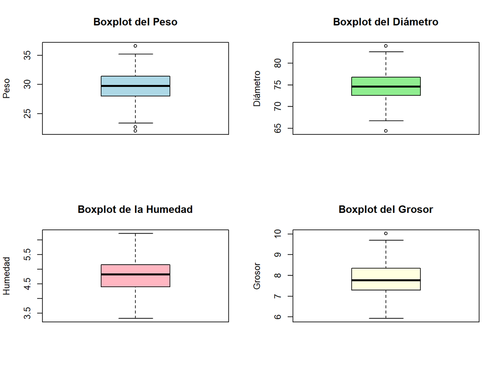

```r
par(mfrow = c(2, 2))

boxplot(
  datos_galleta$peso,
  main = "Boxplot del Peso",
  ylab = "Peso",
  col = "lightblue"
)

boxplot(
  datos_galleta$diametro,
  main = "Boxplot del Diámetro",
  ylab = "Diámetro",
  col = "lightgreen"
)

boxplot(
  datos_galleta$humedad,
  main = "Boxplot de la Humedad",
  ylab = "Humedad",
  col = "lightpink"
)

boxplot(
  datos_galleta$grosor,
  main = "Boxplot del Grosor",
  ylab = "Grosor",
  col = "lightyellow"
)
```

*Los diagramas de caja muestran que el proceso de producción es simétrico y se encuentra estables en sus cuatro variables, ya que las medianas están perfectamente centradas dentro de cada rango intercuartílico. Aunque se aprecian algunos valores atípicos aislados en el peso, el diámetro y el grosor, estos son puntuales y no comprometen la baja dispersión ni la consistencia general del lote.*

### 2.5 Matriz de correlación

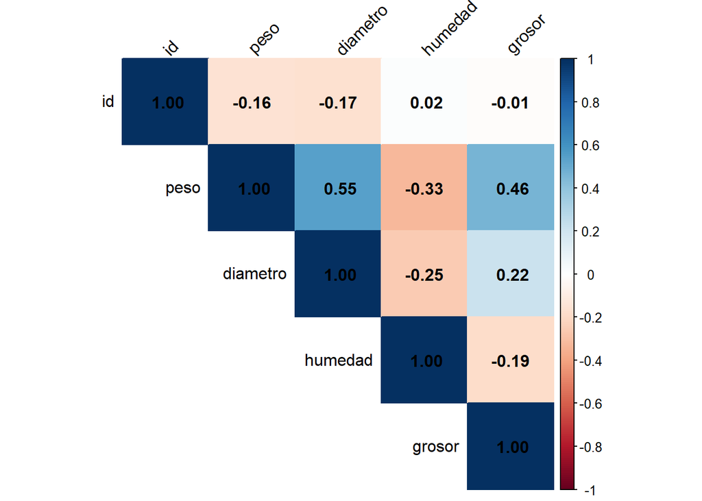

```r
matriz_cor <- cor(datos_galleta)

corrplot(
  matriz_cor,
  method = "color",
  type = "upper",
  addCoef.col = "black",
  tl.col = "black",
  tl.srt = 45
)
```

# 3. Pruebas de supuestos y contraste de hipótesis individuales

### 3.1 Validación de normalidad y prueba t univariada para el peso de la galleta

- $H_0$: Los datos de la variable peso provienen de una distribución normal.
- $H_1$: Los datos de la variable peso no provienen de una distribución normal.
- Nivel de significancia ($\alpha$): 0.05

Para aplicar la prueba t de Student de una muestra, primero verificamos si la variable peso proviene de una distribución normal poblacional mediante las pruebas de Shapiro-Wilk y Lilliefors.

```r
shapiro.test(datos_galleta$peso)
```

```
##
##  Shapiro-Wilk normality test
##
## data:  datos_galleta$peso
## W = 0.99218, p-value = 0.5845
```

```r
lillie.test(datos_galleta$peso)
```

```
##
##  Lilliefors (Kolmogorov-Smirnov) normality test
##
## data:  datos_galleta$peso
## D = 0.067104, p-value = 0.09529
```

*Con un nivel de confianza del 95%, ambas pruebas estadísticas concluyen que no hay evidencia suficiente para rechazar la normalidad de los datos. Por lo tanto, se asume que la variable peso sigue una distribución normal, cumpliendo satisfactoriamente con el supuesto necesario para proceder con la prueba t de Student.*

### 3.2 Contraste de hipótesis (Prueba t)

Una vez comprobada la normalidad en el paso anterior, puedemos aplicar la prueba estadística para verificar si la media del peso coincide con los $30.0\text{ g}$ de la ficha técnica.

- $H_0$: El peso promedio poblacional es igual al estándar de la ficha técnica

  ($\mu = 30.0\text{ g}$).
- $H_1$: El peso promedio poblacional es diferente al estándar

  ($\mu \neq 30.0\text{ g}$).
- Nivel de significancia ($\alpha$): $0.05$

```r
t.test(datos_galleta$peso, alternative = "two.sided", mu = 30.0, conf.level = 0.95)
```

```
##
##  One Sample t-test
##
## data:  datos_galleta$peso
## t = -1.5162, df = 149, p-value = 0.1316
## alternative hypothesis: true mean is not equal to 30
## 95 percent confidence interval:
##  29.26404 30.09689
## sample estimates:
## mean of x
##  29.68047
```

*Con un nivel de confianza del 95%, se concluye que no hay diferencias estadísticamente significativas entre el peso promedio del lote muestreado y el estándar especificado. A pesar de que la media muestral (*$29.68\text{ g}$) es ligeramente inferior al objetivo, esta variación es producto del azar muestral. Por lo tanto, el lote de producción cumple con el parámetro de peso establecido en la ficha técnica.

### *Visualización de la Distribución del Peso frente a la Especificación Técnica*

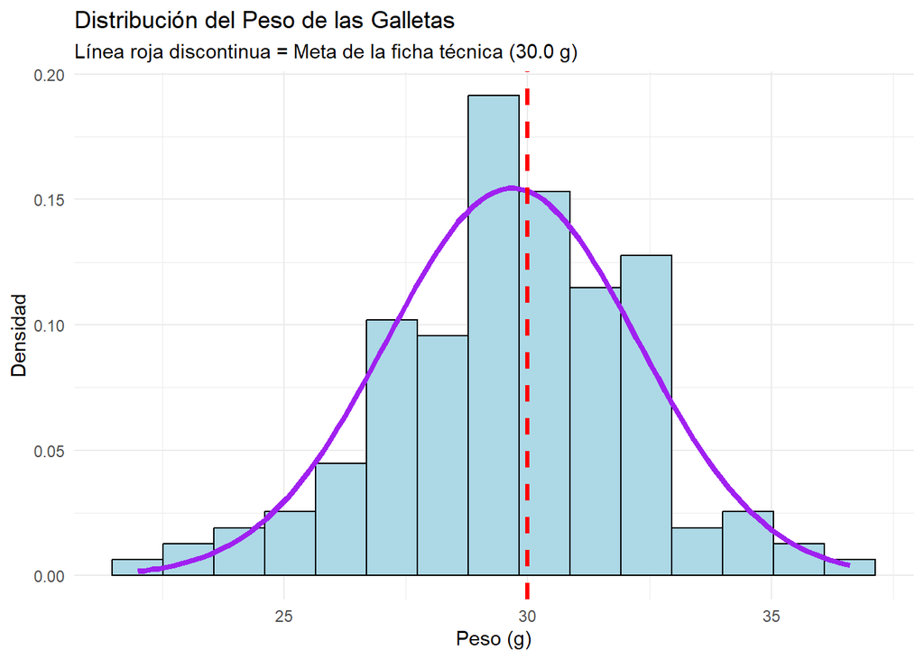

```r
ggplot(datos_galleta, aes(x = peso)) +
  geom_histogram(aes(y = after_stat(density)), bins = 15, fill = "lightblue", color = "black") +
  stat_function(fun = dnorm,
                args = list(mean = mean(datos_galleta$peso), sd = sd(datos_galleta$peso)),
                color = "purple", linewidth = 1.5) +
  geom_vline(xintercept = 30.0, color = "red", linetype = "dashed", linewidth = 1.2) +
  labs(title = "Distribución del Peso de las Galletas",
       subtitle = "Línea roja discontinua = Meta de la ficha técnica (30.0 g)",
       x = "Peso (g)",
       y = "Densidad") +
  theme_minimal()
```

*El gráfico confirma visualmente los resultados de la prueba estadística: El punto más alto de la curva está casi pegado a la línea roja punteada.*

### 4 El efecto (Hedges’ g)

Mientras que la prueba estadística (el p-value) nos dice si existe una diferencia, el tamaño del efecto (Hedges’ g) nos dice qué tan grande o importante es esa diferencia en la vida real.

```r
efecto_peso <- hedges_g(datos_galleta$peso, mu = 30.0)

print(efecto_peso)
```

```
## Hedges' g |        95% CI
## -------------------------
## -0.12     | [-0.28, 0.04]
##
## - Deviation from a difference of 30.
```

```r
interpret_hedges_g(efecto_peso$Hedges_g)
```

```
## [1] "very small"
## (Rules: cohen1988)
```

*Esta función complementa el análisis anterior. No solo se comprueba que no hay diferencia estadística significativa (con la prueba t), sino que además se demuestra que la ligerísima diferencia de peso que existe es prácticamente irrelevante. La producción de galletas está cumpliendo el estándar.*

# 5. Validación de supuestos multivariados: Outliers y Normalidad

## 5.1 Outliers

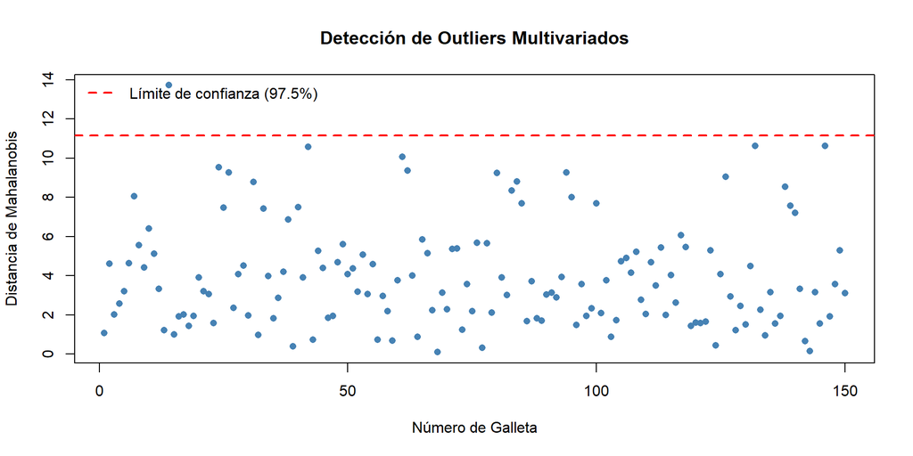

```r
datos_multi <- datos_galleta[, c("peso", "diametro", "humedad", "grosor")]
# 1. Calcular las medias y la matriz de covarianza
medias <- colMeans(datos_multi)
covarianza <- cov(datos_multi)

# 2. Calcular las distancias de Mahalanobis para cada galleta
distancias <- mahalanobis(datos_multi, center = medias, cov = covarianza)

# 3. Dibujar el gráfico
plot(distancias,
     type = "p",
     pch = 16,
     col = "steelblue",
     main = "Detección de Outliers Multivariados",
     ylab = "Distancia de Mahalanobis",
     xlab = "Número de Galleta")

# 4. Agregar la línea límite (usando Chi-cuadrado con 4 grados de libertad)
limite <- qchisq(0.975, df = 4)
abline(h = limite, col = "red", lwd = 2, lty = 2)

# Opcional: Agregar texto explicativo en el gráfico
legend("topleft", legend = c("Límite de confianza (97.5%)"),
       col = "red", lty = 2, lwd = 2, bty = "n")
```

*Al contrastar estas distancias contra el valor crítico de la distribución Chi-cuadrado (con un nivel de confianza del 97.5%), se observa visualmente que prácticamente la totalidad de los datos se mantiene por debajo del límite de control.*

*Únicamente una observación supera la línea de referencia. Dado el tamaño de la muestra (n = 150), la presencia de un solo valor atípico es estadísticamente insignificante y atribuible a la variabilidad natural del proceso.*

## 5.2 Normalidad multivariada (prueba de Shapiro-Wilk)

- H0: Las cuatro características de las galletas (peso, diámetro, humedad y grosor) siguen conjuntamente una distribución normal multivariada.
- H1: Las cuatro características no siguen una distribución normal multivariada.
- Nivel de significancia: 0.05

```r
mshapiro.test(t(as.matrix(datos_multi)))
```

```
##
##  Shapiro-Wilk normality test
##
## data:  Z
## W = 0.98512, p-value = 0.1066
```

*Dado que este valor es superior a nuestro nivel de significancia del 0.05, no existe evidencia estadística para rechazar la hipótesis nula. En conclusión, se confirma que los datos cumplen con el supuesto de normalidad multivariada.*

# 6. Pruebas complementarias de normalidad multivariada

```r
# 1. Test MVN de Royston
royston <- mvn(data = datos_multi, mvn_test = "royston")
royston$multivariate_normality
```

```
##      Test Statistic p.value     Method      MVN
## 1 Royston     0.718   0.949 asymptotic ✓ Normal
```

```r
# 2. Test MVN de Mardia
mardia <- mvn(data = datos_multi, mvn_test = "mardia")
mardia$multivariate_normality
```

```
##              Test Statistic p.value     Method      MVN
## 1 Mardia Skewness    14.637   0.797 asymptotic ✓ Normal
## 2 Mardia Kurtosis    -0.691   0.490 asymptotic ✓ Normal
```

```r
# 3. Test MVN de Henze-Zirkler
hz <- mvn(data = datos_multi, mvn_test = "hz")
hz$multivariate_normality
```

```
##            Test Statistic p.value     Method      MVN
## 1 Henze-Zirkler     0.712   0.906 asymptotic ✓ Normal
```

```r
# 4. Test MVN de Doornik-Hansen
dh <- mvn(data = datos_multi, mvn_test = "doornik_hansen")
dh$multivariate_normality
```

```
##             Test Statistic df p.value     Method          MVN
## 1 Doornik-Hansen   372.283  8  <0.001 asymptotic ✗ Not normal
```

```r
# 5. Test MVN de Szekely-Rizzo (Energy)
energy <- mvn(data = datos_multi, mvn_test = "energy")
energy$multivariate_normality
```

```
##          Test Statistic p.value    Method      MVN
## 1 E-Statistic     0.891   0.852 bootstrap ✓ Normal
```

*Como la gran mayoría de las pruebas complementarias (4 de 5) respaldan el resultado que ya se había obtenido con Shapiro-Wilk, puedemos afirmar con total seguridad que los datos cumplen con el supuesto de normalidad multivariada.*

# 7. Contraste de hipótesis multivariado: prueba $T^2$ de Hotelling

Evaluar si las cuatro variables (peso, diámetro, humedad y grosor) cumplen en conjunto con la ficha técnica.

- H0: El vector de medias poblacional es igual a la especificación técnica
- H1: El vector de medias poblacional difiere de la especificación técnica

```r
# Vector objetivo de la ficha técnica: Peso=30, Diametro=75, Humedad=4.5, Grosor=8
mu_objetivo <- c(30.0, 75.0, 4.5, 8.0)

HotellingsT2(datos_multi, mu = mu_objetivo)
```

```
##
##  Hotelling's one sample T2-test
##
## data:  datos_multi
## T.2 = 10.657, df1 = 4, df2 = 146, p-value = 1.322e-07
## alternative hypothesis: true location is not equal to c(30,75,4.5,8)
```

*Existe evidencia estadística contundente para concluir que el vector de medias de tu muestra difiere significativamente de la especificación técnica exigida. En resumen: evaluando las cuatro características en conjunto, el lote de galletas no cumple con los estándares de calidad.*

# 8. Regiones de confianza bivariadas

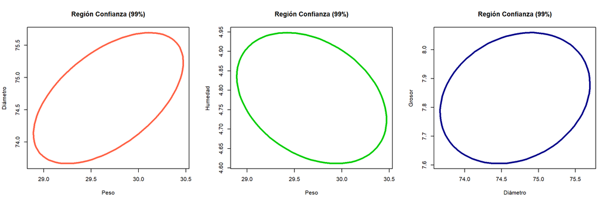

```r
library(ellipse)
n <- nrow(datos_multi)
p <- ncol(datos_multi)
xbar <- colMeans(datos_multi)
S <- cov(datos_multi)

# Constante de confianza para la media
tconst <- sqrt((p / n) * ((n - 1) / (n - p)) * qf(0.99, p, n - p))

par(mfrow = c(1, 3)) # Divide la pantalla en 3 columnas

# Gráfico 1: Peso vs Diámetro
plot(ellipse(x = S[c(1, 2), c(1, 2)], centre = xbar[c(1, 2)], t = tconst),
     type = "l", xlab = "Peso", ylab = "Diámetro", col = "tomato", lwd = 3,
     main = "Región Confianza (99%)")

# Gráfico 2: Peso vs Humedad
plot(ellipse(x = S[c(1, 3), c(1, 3)], centre = xbar[c(1, 3)], t = tconst),
     type = "l", xlab = "Peso", ylab = "Humedad", col = "green3", lwd = 3,
     main = "Región Confianza (99%)")

# Gráfico 3: Diámetro vs Grosor
plot(ellipse(x = S[c(2, 4), c(2, 4)], centre = xbar[c(2, 4)], t = tconst),
     type = "l", xlab = "Diámetro", ylab = "Grosor", col = "darkblue", lwd = 3,
     main = "Región Confianza (99%)")
```

```r
par(mfrow = c(1, 1)) # Restaura la ventana
```

*El análisis visual bivariado confirma el rechazo de la hipótesis multivariada ($T^2$ de Hotelling). El incumplimiento del lote no se debe al peso ni al diámetro, sino a un exceso de humedad en la formulación o proceso de horneado, el cual está desplazando el promedio real de producción fuera de las especificaciones técnicas aceptables.*

# 9. Intervalos de confianza simultáneos

```r
T.ci <- function(mu, Sigma, n, avec = rep(1, length(mu)), level = 0.95) {
  p <- length(mu)
  cval <- qf(level, p, n - p) * p * (n - 1) / (n - p)
  zhat <- crossprod(avec, mu)
  zvar <- crossprod(avec, Sigma %*% avec) / n
  const <- sqrt(cval * zvar)
  c(lower = zhat - const, upper = zhat + const)
}

TCI <- tCI <- bon <- chi <- NULL
alpha_bon <- 1 - 0.05 / (2 * p) # Nivel ajustado para Bonferroni

for (k in 1:p) {
  avec <- rep(0, p)
  avec[k] <- 1

  # 1. Hotelling T^2 Simultáneo
  TCI <- c(TCI, T.ci(xbar, S, n, avec))
  # 2. Clásico t de Student (individual)
  tCI <- c(tCI, xbar[k] - sqrt(S[k, k] / n) * qt(0.975, df = n - 1),
                xbar[k] + sqrt(S[k, k] / n) * qt(0.975, df = n - 1))
  # 3. Método de Bonferroni
  bon <- c(bon, xbar[k] - sqrt(S[k, k] / n) * qt(alpha_bon, df = n - 1),
                xbar[k] + sqrt(S[k, k] / n) * qt(alpha_bon, df = n - 1))
  # 4. Aproximación Chi-cuadrado (muestras grandes)
  chi <- c(chi, xbar[k] - sqrt(S[k, k] / n) * sqrt(qchisq(0.95, df = p)),
                xbar[k] + sqrt(S[k, k] / n) * sqrt(qchisq(0.95, df = p)))
}

# Consolidar en una tabla limpia
tabla_intervalos <- rbind(TCI, tCI, bon, chi)
rownames(tabla_intervalos) <- c("Simultáneo_T2", "Clásico_t", "Bonferroni", "Aprox_Chi2")
colnames(tabla_intervalos) <- c("Peso_Inf", "Peso_Sup", "Diam_Inf", "Diam_Sup",
                                "Hum_Inf", "Hum_Sup", "Grosor_Inf", "Grosor_Sup")

round(tabla_intervalos, 2)
```

```
##               Peso_Inf Peso_Sup Diam_Inf Diam_Sup Hum_Inf Hum_Sup Grosor_Inf
## Simultáneo_T2    29.02    30.34    73.83    75.53    4.64    4.92       7.64
## Clásico_t        29.26    30.10    74.15    75.21    4.69    4.87       7.71
## Bonferroni       29.15    30.21    74.00    75.36    4.67    4.89       7.68
## Aprox_Chi2       29.03    30.33    73.85    75.51    4.64    4.92       7.65
##               Grosor_Sup
## Simultáneo_T2       8.02
## Clásico_t           7.95
## Bonferroni          7.99
## Aprox_Chi2          8.02
```

*La evidencia estadística demuestra numéricamente que el lote de producción no cumple con la especificación técnica general debido, única y exclusivamente, a un exceso de humedad. Las galletas presentan un nivel de humedad real superior al $4.64\%$, lo que amerita una revisión en los tiempos o temperaturas de la fase de horneado.*

## 10. Regiones de predicción (futuras observaciones)

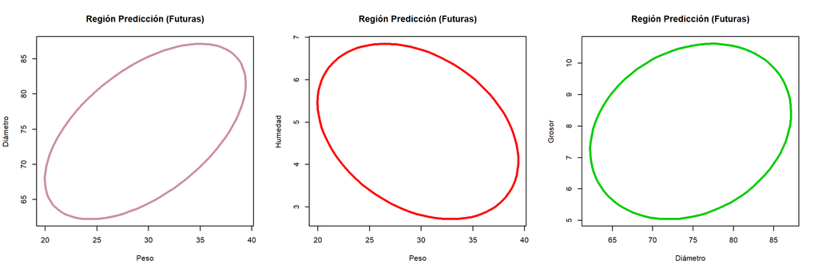

```r
# Constante para la región de predicción de nuevas observaciones
pconst <- sqrt((p / n) * ((n^2 - 1) / (n - p)) * qf(0.99, p, n - p))

par(mfrow = c(1, 3)) # Divide la pantalla en 3 columnas

# 1: Predicción Peso vs Diámetro
plot(ellipse(x = S[c(1, 2), c(1, 2)], centre = xbar[c(1, 2)], t = pconst),
     type = "l", xlab = "Peso", ylab = "Diámetro", col = "pink3", lwd = 3,
     main = "Región Predicción (Futuras)")

# 2: Predicción Peso vs Humedad
plot(ellipse(x = S[c(1, 3), c(1, 3)], centre = xbar[c(1, 3)], t = pconst),
     type = "l", xlab = "Peso", ylab = "Humedad", col = "red", lwd = 3,
     main = "Región Predicción (Futuras)")

# 3: Predicción Diámetro vs Grosor
plot(ellipse(x = S[c(2, 4), c(2, 4)], centre = xbar[c(2, 4)], t = pconst),
     type = "l", xlab = "Diámetro", ylab = "Grosor", col = "green3", lwd = 3,
     main = "Región Predicción (Futuras)")
```

```r
par(mfrow = c(1, 1))
```

*Aunque el promedio poblacional de la humedad falló el control de calidad (el lote en general es muy húmedo), la variabilidad del proceso productivo es tan grande que es posible y probable que muchas galletas individuales sí cumplan con la especificación exacta de humedad del 4.5%. Sin embargo, desde la perspectiva del control de calidad industrial, el proceso necesita ser calibrado urgentemente, no solo para reducir los niveles promedio de humedad, sino también para disminuir esta inmensa variabilidad entre una galleta y otra.*